# Homework 3

Political Science Research Methods The Institute of Political Science Leiden University s.rezaeedaryakenari@fsw.leidenuniv.nl Instructor: Dr. Babak Rezaee Daryakenari

Spring 2020

The assignment is due on Friday May 22, by 17:00  
Submit your responses as an *$\mathcal{R}$ markdown* file via Blackboard. *Good luck!*

In a recently accepted paper by Research & Politics, my co-author and I explore the effects of providing information on individuals support for nonviolent resistance in an experimental survey. The draft of the paper is available [here](https://www.dropbox.com/s/rkic2kjzl37oza4/RezaeeAsadzadeh_RandP.pdf?dl=0). We will use a modified version of the collected data in this study. The collected data is available from my GitHub page: [here](https://raw.githubusercontent.com/babakrezaee/MethodsCourses/master/LeidenUniv_MAQM2020/Datasets/R%26P_RezaeeAsadzadeh_MethodsCourse.csv)

Before assigning the participants in the experiment to control and treatment groups, we asked some questions to measure some of important socio-economic factors and pre-experiment attitude toward nonviolent and violent methods of resistance. In one of the questions, the participants are asked:

*From a scale of 1 to 10, ten (10) being the highest, how would you rate the following names as your favorite political figures?*

Gandhi, Mandela, Che, Martin Luther King (MLK), and Malcolm X X.

Let’s first take a look at the distribution of responses:

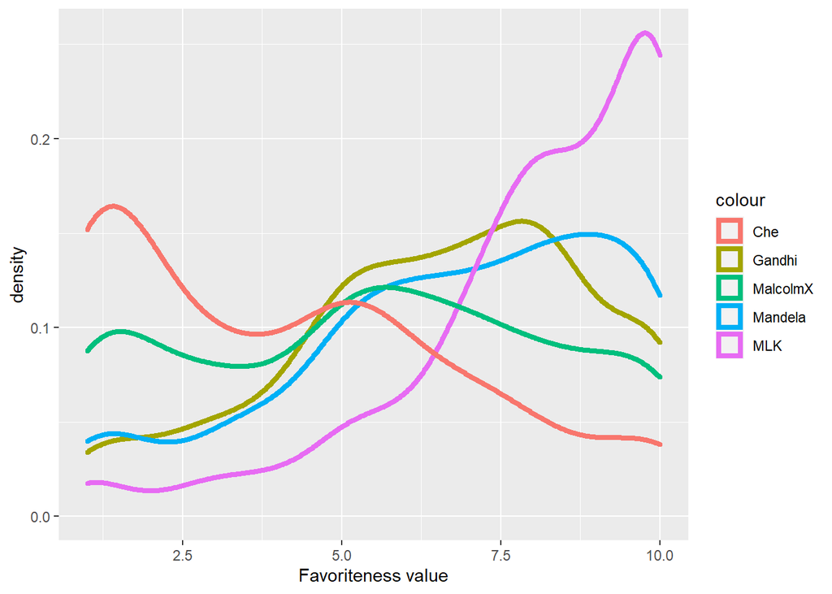

```r
data_cl=read.csv("https://raw.githubusercontent.com/babakrezaee/MethodsCourses/master/LeidenUniv_MAQM2020/Datasets/R%26P_RezaeeAsadzadeh_MethodsCourse.csv")

library(ggplot2)
ggplot(data=data_cl)+
   geom_density(aes(x=Gandhi, colour= "Gandhi"), lwd=1.5)+
   geom_density(aes(x=Mandela, colour= "Mandela"), lwd=1.5)+
   geom_density(aes(x=MLK, colour= "MLK"), lwd=1.5)+
   geom_density(aes(x=MalcomX, colour= "MalcolmX"), lwd=1.5)+
   geom_density(aes(x=Che, colour= "Che"), lwd=1.5)+
  labs(x = "Favoriteness value")
```

Let’s see how the participants view about Mandela and Malcolm X affected their view about nonviolent(resistance):

```r
library(jtools)

ml_OLS1=lm(Nonviolent_effective~Mandela, data=data_cl)

ml_OLS2=lm(Nonviolent_effective~Mandela+MalcomX, data=data_cl)


summ(ml_OLS1)
```

```
## MODEL INFO:
## Observations: 404 (32 missing obs. deleted)
## Dependent Variable: Nonviolent_effective
## Type: OLS linear regression
##
## MODEL FIT:
## F(1,402) = 27.73, p = 0.00
## R² = 0.06
## Adj. R² = 0.06
##
## Standard errors: OLS
## -----------------------------------------------
##                     Est.   S.E.   t val.      p
## ----------------- ------ ------ -------- ------
## (Intercept)         5.41   0.31    17.50   0.00
## Mandela             0.23   0.04     5.27   0.00
## -----------------------------------------------
```

```r
summ(ml_OLS2)
```

```
## MODEL INFO:
## Observations: 392 (44 missing obs. deleted)
## Dependent Variable: Nonviolent_effective
## Type: OLS linear regression
##
## MODEL FIT:
## F(2,389) = 15.07, p = 0.00
## R² = 0.07
## Adj. R² = 0.07
##
## Standard errors: OLS
## ------------------------------------------------
##                      Est.   S.E.   t val.      p
## ----------------- ------- ------ -------- ------
## (Intercept)          5.42   0.32    16.96   0.00
## Mandela              0.27   0.05     5.10   0.00
## MalcomX             -0.06   0.05    -1.18   0.24
## ------------------------------------------------
```

These results can be written as below equations:

$$\begin{equation}
Nonviolent\_effective=5.41+.23 \times Mandela+\epsilon
\end{equation}$$

$$\begin{equation}
Nonviolent\_effective=5.42+.27 \times Mandela-.06 \times MalcolmX+\epsilon
\end{equation}$$

**1. Interpret the estimation results reported in the above tables for ${\tt ml\_OLS1}$ and ${\tt ml\_OLS2}$. What are the estimated coefficients. Are they statistically significant? How is the explanatory power of these models?**

**2. What are the predicted support for the effectiveness of nonviolent movements if a participants in the survey reports a little (4) interest/favorite for Mandela and a great deal (9) of interest/favorite for Malcolm X? Use both ${\tt ml\_OLS1}$ and ${\tt ml\_OLS2}$ models, and compare you findings.**

When we calculate the predicted values for several points of our independent variable of, we can explore what is the predicted effect of the independent variable on the outcome variable. To do so, we can use ${\tt effect\_plot()}$ from ${\tt jtools}$ package. Below plot shows that predicted effects of attitude toward Mandela on the participants’ view about the effectiveness of nonviolent resistance.

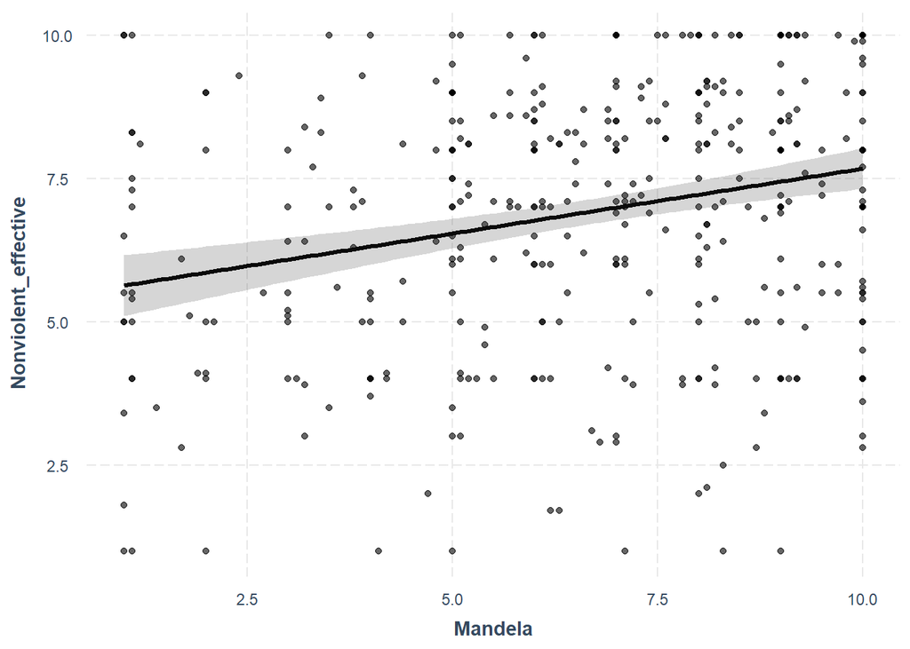

```r
effect_plot(ml_OLS1, pred = Mandela, interval = TRUE, plot.points = TRUE)
```

**3. Assume that someone asks you to include some demographic variables such as age, marriage status, and gender to {ml_OLS2}. Estimate this model (let’s call it {ml_OLS3}) and plot the effect of Mandela, age, and gender on the participants’ predicted attitude toward nonviolent resistance. Do you see any relation between the predicted effect of explanatory variables and their predicted probability.**

**4. Assume that ${\tt ml_OLS3}$ is one of your final models that you want to report in your paper. Check if this model satisfies the Gauss-Markov’s BLUE assumptions. Try to fix these problems based on the suggested remedies in class.**

It is usually common that scholars develop theories about the conditional effects of one variable on the association between two variables. For example, if we study the effect of ${\tt Religiosity}$ on the attitude toward the effectiveness of nonviolent resistance, we find that these two variables are positively associated:

```
## MODEL INFO:
## Observations: 435 (1 missing obs. deleted)
## Dependent Variable: Nonviolent_effective
## Type: OLS linear regression
##
## MODEL FIT:
## F(1,433) = 4.79, p = 0.03
## R² = 0.01
## Adj. R² = 0.01
##
## Standard errors: OLS
## -----------------------------------------------
##                     Est.   S.E.   t val.      p
## ----------------- ------ ------ -------- ------
## (Intercept)         6.55   0.20    32.21   0.00
## Religiosity         0.08   0.04     2.19   0.03
## -----------------------------------------------
```

Someone might claim that this association is mediated by/conditional on the gender of respondents. To evaluate these types of arguments, we use *interaction* models. The mathematical formulation of an interaction model is as follow:

$$\begin{equation}
y=\beta_0+\beta_1 x_1+\beta_2 x_2+\beta_3 x_1 \times x_2+\epsilon
\end{equation}$$

In our above example, the equation is:

$$\begin{equation}
Nonviolent\_effective=\beta_0+ \beta_1 Religiosity+ \beta_2 Gender+\beta_3 Religiosity \times Gender+\epsilon
\end{equation}$$

We can estimate/run an interaction model in $\mathcal{R}$ as follow:

```r
ml_OLS5=lm(Nonviolent_effective~Religiosity+Gender+Religiosity*Gender, data=data_cl)

summ(ml_OLS5)
```

```
## MODEL INFO:
## Observations: 435 (1 missing obs. deleted)
## Dependent Variable: Nonviolent_effective
## Type: OLS linear regression
##
## MODEL FIT:
## F(3,431) = 3.99, p = 0.01
## R² = 0.03
## Adj. R² = 0.02
##
## Standard errors: OLS
## -----------------------------------------------------------
##                                 Est.   S.E.   t val.      p
## ---------------------------- ------- ------ -------- ------
## (Intercept)                     7.13   0.35    20.40   0.00
## Religiosity                     0.04   0.06     0.57   0.57
## GenderMale                     -0.87   0.43    -2.03   0.04
## Religiosity:GenderMale          0.06   0.08     0.81   0.42
## -----------------------------------------------------------
```

Although we can interpret the results of interaction models, political methodologists[^1] suggest that we use the predicted effects plots to analyze the interaction models as these models are more complex due to their direct and conditional effects. The regression table shows that gender does not have a statistically significant effect on the association between ${\tt Religiosity}$ and the attitude toward the effectiveness of nonviolent resistance. But how does the predictive plot look like? To create the predictive effects of an interaction model, we use ${\tt plot\_model()}$ form ${\tt sjPlot}$ package.

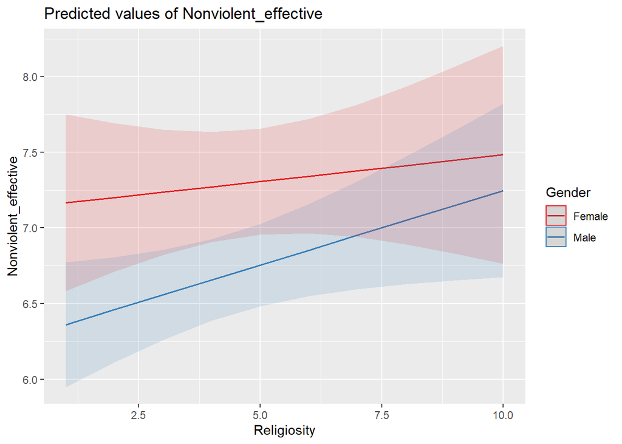

```r
library(sjPlot)
plot_model(ml_OLS5, type = "pred", terms = c("Religiosity", "Gender"))
```

**5. Estimate a model that evaluates the conditional effect of ${\tt Marriage}$ on the association between ${\tt Religiosity}$ and the attitude toward the effectiveness of nonviolent resistance. Plot this interaction effect. Interpret your results.**

[^1]: For example, see: Brambor, T., W. R. Clark, and M. Golder. (2006) Understanding Interaction Models: Improving Empirical Analyses. *Political Analysis*, 14(1):63–82